# Effects of urban green infrastructure on supply provision of ecosystem service: Temperature reduction

Irina Lerner

30/01/24

# Data

The data set is a 100m² grid over the city of São Paulo. The temperature control variable is represented by DT. Proportion of vegetation is prop_veg and EVI for the region is EVI_mean (since EVI map is a 30m² grid, there is ~ 9 EVI cells in a 100m² grid).

We begin exploring the response data.

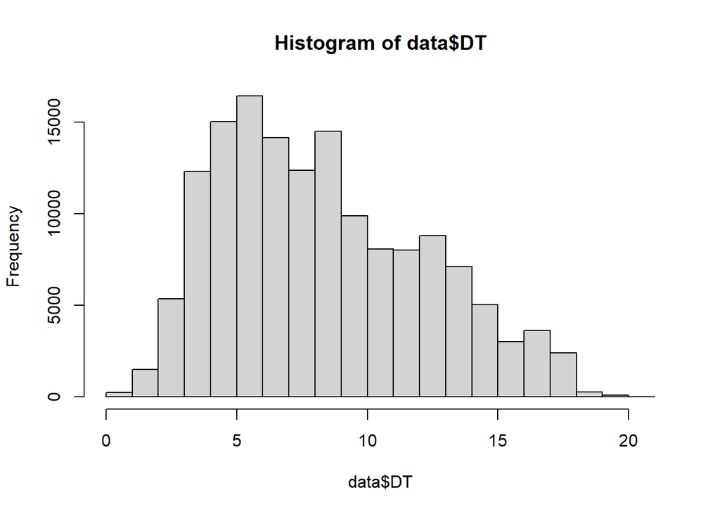

```r
hist(data$DT)
```

We can already see its not normally distibuited. What factors may influence?

Microclimatic region might have a big effect on data.

```r
model <- lm(res ~ RM, data)
pAIC <- analyse_linear_model(data, model)
```

```
## [1] "Residuals not normally distributed:"
## [1] "They're skewed to the right"
## [1] "model improved!"
## [1] "model stats"
## [1] 806752.7
```

```r
anova(model)
```

```
## Analysis of Variance Table
##
## Response: res
##               Df  Sum Sq Mean Sq F value    Pr(>F)
## RM             1  251090  251090   18530 < 2.2e-16 ***
## Residuals 148180 2007932      14
## ---
## Signif. codes:  0 '***' 0.001 '**' 0.01 '*' 0.05 '.' 0.1 ' ' 1
```

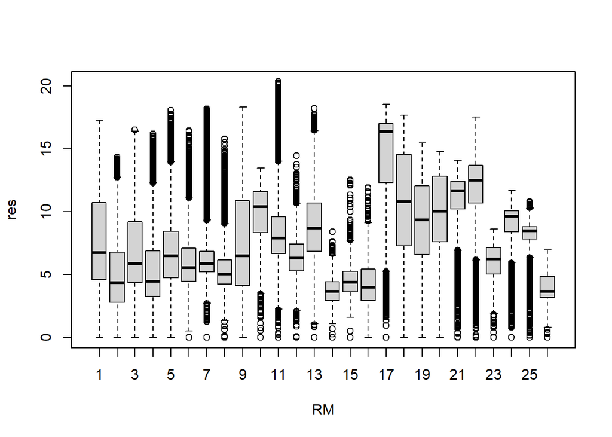

```r
boxplot(res ~ RM, data)
```

Anova shows significant influence of the micro climatic region in each group. This might have to be included as a random factor. Looking into each group’s distribution, we can see that there is a lot of differences

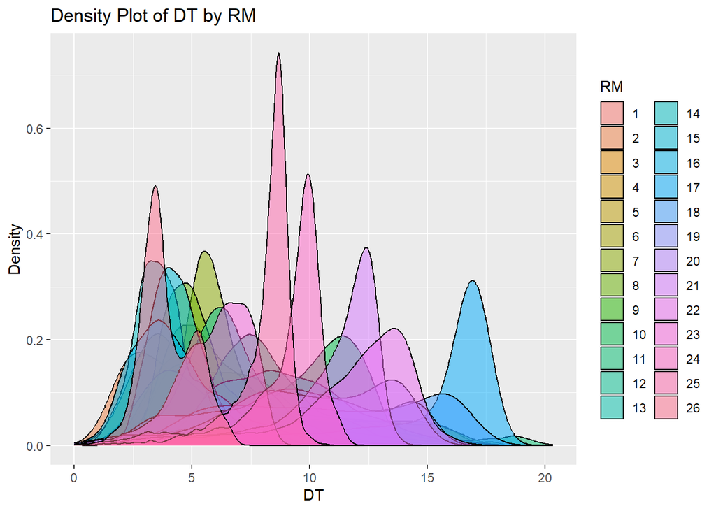

```r
ggplot(data, aes(x = DT, fill = factor(RM))) +
  geom_density(alpha = 0.5) +
  labs(title = "Density Plot of DT by RM", x = "DT", y = "Density", fill = "RM")
```

Analyzing a known effect agains temperature, the effect of proportion of vegetation, we see improvement but distribuition is still not normal.

```r
model <- lm(res ~ prop_veg + RM, data)
anova(model)
```

```
## Analysis of Variance Table
##
## Response: res
##               Df  Sum Sq Mean Sq  F value    Pr(>F)
## prop_veg       1 1087226 1087226 143828.9 < 2.2e-16 ***
## RM             1   51687   51687   6837.6 < 2.2e-16 ***
## Residuals 148179 1120109       8
## ---
## Signif. codes:  0 '***' 0.001 '**' 0.01 '*' 0.05 '.' 0.1 ' ' 1
```

```r
pAIC <- analyse_linear_model(data, model, pAIC)
```

```
## [1] "Residuals not normally distributed:"
## [1] "They're skewed to the right"
## [1] "model improved!"
## [1] "model stats"
## [1] 720264
```

Definitely proportion of vegetation has an effect, since this is a really small p-value!

But again, residuals are not normally distributed. The function describing the temperature relief seems to be nonlinear.

Probably the effect of urban land is significant as well, so in different categories for urban occupation, we can see that distributions vary

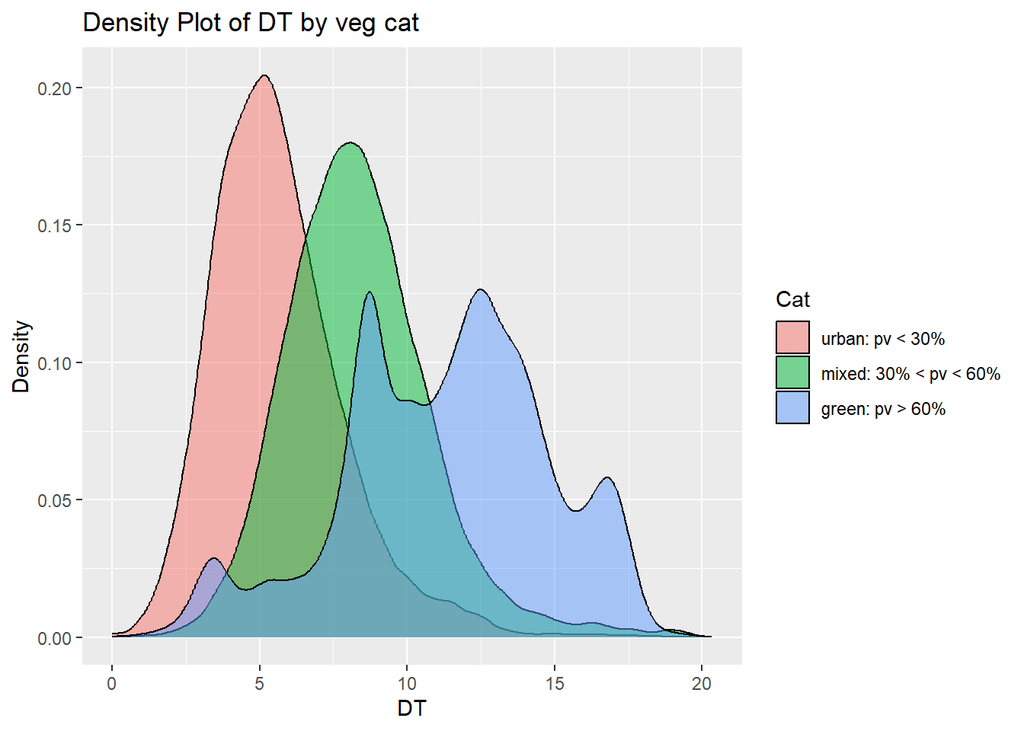

```r
ggplot(data, aes(x = DT, fill = factor(Category))) +
  geom_density(alpha = 0.5) +
  labs(title = "Density Plot of DT by veg cat", x = "DT", y = "Density", fill = "Cat")
```

specially in areas considered green. What is happening here?

A proxy for vegetation amount is the EVI. EVI is a bit more explanatory than proportion of vegetation. It considers the mean color of the surface, considering green and grey.

“The Enhanced Vegetation Index (EVI) is a satellite-derived index designed to optimize the vegetation signal with improved sensitivity in high biomass regions and improved vegetation monitoring through a de-coupling of the canopy background signal and a reduction in atmosphere influences.

EVI is an improvement over the more common Normalized Difference Vegetation Index (NDVI), which can be saturated in high biomass areas. This saturation can make NDVI less sensitive to differences in dense vegetation. Additionally, NDVI can be influenced by soil background and atmospheric conditions, which can obscure the true vegetation signal.

EVI better detects and quantifies:

- Vegetation vigor and productivity
- Canopy structural variations, including leaf density and type, as well as plant phenology
- Changes in vegetation cover, including monitoring of vegetation dynamics over time
- Stress and disturbances in plant growth Agricultural monitoring and forecasting”

Since EVI is more sensitive to vegetation structure and density, it can be used to relate to temperature, accounting for detailed information not contained in prop_veg.

```r
model <- lm(res ~ EVI_mean + RM, data)
pAIC <- analyse_linear_model(data, model, pAIC)
```

```
## [1] "Residuals not normally distributed:"
## [1] "They're skewed to the right"
## [1] "model improved!"
## [1] "model stats"
## [1] 715724.4
```

Model is better it is still not normally distributed. We now divide it into categories (SUVI for urban, SVI for mixed, SGVI for unmixed) It is based on EVI values.

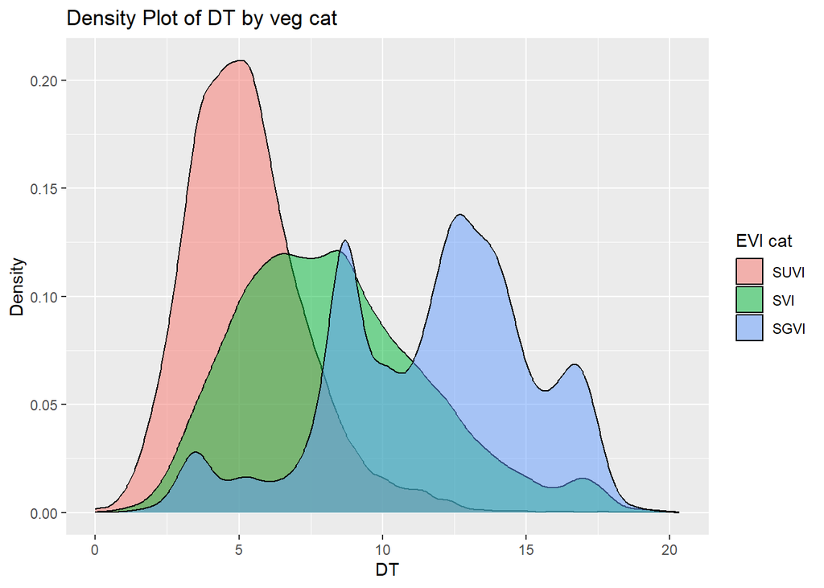

```r
ggplot(data[!is.na(data$EVI_category),], aes(x = DT, fill = factor(EVI_category))) +
  geom_density(alpha = 0.5) +
  labs(title = "Density Plot of DT by veg cat", x = "DT", y = "Density", fill = "EVI cat")
```

We can see that variance is different in each category. Also, the model does improves from vegetation proportion.

The need for a more complex model using another family and allowing mixed effects is clear, but we need first to look into our response variables relationships.

```r
model <- lm(EVI_mean ~ prop_veg, data[!is.na(data$EVI_category),])
pAIC <- analyse_linear_model(data, model)
```

```
## [1] "Residuals not normally distributed:"
## [1] "They're skewed to the right"
## [1] "model improved!"
## [1] "model stats"
## [1] -322488.9
```

```r
summary(model)
```

```
##
## Call:
## lm(formula = EVI_mean ~ prop_veg, data = data[!is.na(data$EVI_category),
##     ])
##
## Residuals:
##      Min       1Q   Median       3Q      Max
## -0.61501 -0.03761 -0.00301  0.03282  0.86827
##
## Coefficients:
##              Estimate Std. Error t value Pr(>|t|)
## (Intercept) 0.0942749  0.0003302   285.5   <2e-16 ***
## prop_veg    0.5305920  0.0005241  1012.4   <2e-16 ***
## ---
## Signif. codes:  0 '***' 0.001 '**' 0.01 '*' 0.05 '.' 0.1 ' ' 1
##
## Residual standard error: 0.0805 on 146515 degrees of freedom
## Multiple R-squared:  0.8749, Adjusted R-squared:  0.8749
## F-statistic: 1.025e+06 on 1 and 146515 DF,  p-value: < 2.2e-16
```

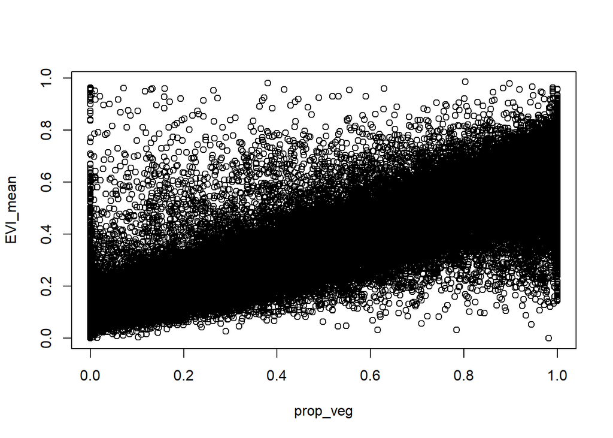

```r
plot(EVI_mean ~ prop_veg, data)
```

The model has a very low AIC showing a clear relationship, but residuals are not normally distribuited. Differences in extremities may turn it a bit. What is being considered?

```r
model <- lm(EVI_mean ~ prop_veg + VV + VH + BV + BH, data)
pAIC <- analyse_linear_model(data, model, pAIC)
```

```
## [1] "Residuals not normally distributed:"
## [1] "They're skewed to the right"
## [1] "model is worse than before"
```

```r
summary(model)
```

```
##
## Call:
## lm(formula = EVI_mean ~ prop_veg + VV + VH + BV + BH, data = data)
##
## Residuals:
##      Min       1Q   Median       3Q      Max
## -0.53489 -0.02576 -0.00275  0.02139  0.81983
##
## Coefficients:
##               Estimate Std. Error t value Pr(>|t|)
## (Intercept)  1.392e-01  7.339e-04 189.671  < 2e-16 ***
## prop_veg     5.116e-01  1.190e-03 429.849  < 2e-16 ***
## VV           5.419e-07  1.476e-08  36.709  < 2e-16 ***
## VH          -4.986e-03  1.026e-04 -48.608  < 2e-16 ***
## BV           6.533e-08  1.219e-08   5.359  8.4e-08 ***
## BH          -2.746e-03  6.049e-05 -45.397  < 2e-16 ***
## ---
## Signif. codes:  0 '***' 0.001 '**' 0.01 '*' 0.05 '.' 0.1 ' ' 1
##
## Residual standard error: 0.0577 on 98316 degrees of freedom
##   (49860 observations deleted due to missingness)
## Multiple R-squared:  0.8825, Adjusted R-squared:  0.8825
## F-statistic: 1.476e+05 on 5 and 98316 DF,  p-value: < 2.2e-16
```

```r
vif(model)
```

```
## prop_veg       VV       VH       BV       BH
## 3.636050 5.477704 2.893529 3.528522 2.555285
```

Adding other components make models worse, but they’re not co linear as VIF shows. Summary indicates that each of these elements affects

Another aspect of response and predictor variables is the spatial relationship, since we are talking about a map.

```r
# For example, defining neighbors based on contiguity (sharing a boundary):
neighbors <- poly2nb(data)
weights <- nb2listw(neighbors, style="W", zero.policy=TRUE)
moran.test(data$DT, weights)
```

```
##
##  Moran I test under randomisation
##
## data:  data$DT
## weights: weights
##
## Moran I statistic standard deviate = 701.56, p-value < 2.2e-16
## alternative hypothesis: greater
## sample estimates:
## Moran I statistic       Expectation          Variance
##      9.194229e-01     -6.748504e-06      1.717521e-06
```

```r
moran.test(data$prop_veg, weights)
```

```
##
##  Moran I test under randomisation
##
## data:  data$prop_veg
## weights: weights
##
## Moran I statistic standard deviate = 673.93, p-value < 2.2e-16
## alternative hypothesis: greater
## sample estimates:
## Moran I statistic       Expectation          Variance
##      8.832087e-01     -6.748504e-06      1.717533e-06
```

Morans’ I test show a lot of spatial correlation not accounted for in the models.

From now on, to build a model, we need to include: 1 - Micro climatic region as a random factor 2 - Spatial relationships. 3 - non-linear or non-gaussian effects

Turning now to other families for our models, to generalized mixed models.

## QUESTION

For Artur: is RM already included in DT? Or only in DT_wait?

For Doug: What does the EVI actually represents?

For Melina: Why would I use a NB dist for pop if I’m using density? Should we change?

(The amount of NA shows I have to reacess my data)